# SpeedDating - prediciting success in speed dating

T. Evgeniou; adapted by team

# Speed dating insights

## The “Business Decision”

We would like to understand how people rate themselves across **five attributes** (attractiveness, sincerity, intelligence, fun and ambition) and how this compares to the ratings they get from their dating partners.

## The Data

We used the data from speed dating experiment conducted at Columbia Business School [available on kaggle](https://www.kaggle.com/annavictoria/speed-dating-experiment). Refer to [docummentation](https://www.kaggle.com/annavictoria/speed-dating-experiment/downloads/speed-dating-experiment.zip) for more details about used attributes or jump to the segmentation section for short description.

This is how the first 5 out of the total of 5656 rows look:

|  | 01 | 02 | 03 | 04 | 05 |
| --- | --- | --- | --- | --- | --- |
| attr_o | 6 | 7 | 10 | 7 | 8 |
| sinc_o | 8 | 8 | 10 | 8 | 7 |
| intel_o | 8 | 10 | 10 | 9 | 9 |
| fun_o | 8 | 7 | 10 | 8 | 6 |
| amb_o | 8 | 7 | 10 | 9 | 9 |
| shar_o | 6 | 5 | 10 | 8 | 7 |
| field_cd | 1 | 1 | 1 | 1 | 1 |
| race | 4 | 4 | 4 | 4 | 4 |
| income | 165 | 165 | 165 | 165 | 165 |
| goal | 2 | 2 | 2 | 2 | 2 |
| date | 7 | 7 | 7 | 7 | 7 |
| go_out | 1 | 1 | 1 | 1 | 1 |
| career | 220 | 220 | 220 | 220 | 220 |
| career_c |  |  |  |  |  |
| sports | 9 | 9 | 9 | 9 | 9 |
| tvsports | 2 | 2 | 2 | 2 | 2 |
| exercise | 8 | 8 | 8 | 8 | 8 |
| dining | 9 | 9 | 9 | 9 | 9 |
| museums | 1 | 1 | 1 | 1 | 1 |
| art | 1 | 1 | 1 | 1 | 1 |
| hiking | 5 | 5 | 5 | 5 | 5 |
| gaming | 1 | 1 | 1 | 1 | 1 |
| clubbing | 5 | 5 | 5 | 5 | 5 |
| reading | 6 | 6 | 6 | 6 | 6 |
| tv | 9 | 9 | 9 | 9 | 9 |
| theater | 1 | 1 | 1 | 1 | 1 |
| movies | 10 | 10 | 10 | 10 | 10 |
| concerts | 10 | 10 | 10 | 10 | 10 |
| music | 9 | 9 | 9 | 9 | 9 |
| shopping | 8 | 8 | 8 | 8 | 8 |
| yoga | 1 | 1 | 1 | 1 | 1 |

## The Process

The “high level” process template to derive high level insights from the speed dating database is split in 3 parts:

1. *Part 1*: We use descrictive statistics (e.g. mean, standard deviation) to understand whether men and women tend to overvalue or undervalue themselves across the five studied attributes
2. *Part 2*: We run hypothesis testing to estimate whether we can accept or reject with 99% confidence that men and women overvalue themselves
3. *Part 3*: We plot the self-ratings of men and women against the ratings given by their dating-partners and we look for patterns of over/undervaluation across the two sexes

# Descriptive Statistics

## Self-perception vs partner’s rating

For each participant we estimated the difference between his/her self-rating and that of the dating partner for the total rating as well as for each of the five attributes. Then we computed the mean and st deviation of that difference for the total population and then for men and women separately. Looking at the fraction of people that overvalue or unervalue themselves can provide us with meaningful insights about self-perception and dating behavior

|  | Overall_Avg_delta | % | Avg_Attr_Delta | Attr_% | Avg_Sinc_Delta | Sinc_% | Avg_Intel_Delta | Intel_% | Avg_Fun_Delta | Fun_% | Avg_Amb_Delta | Amb_% |
| --- | --- | --- | --- | --- | --- | --- | --- | --- | --- | --- | --- | --- |
| Overall | -0.8 |  | -0.67 |  | -0.64 |  | -0.87 |  | -0.91 |  | -0.91 |  |
| Men | -0.77 |  | -0.75 |  | -0.51 |  | -0.92 |  | -0.89 |  | -0.77 |  |
| Women | -0.83 |  | -0.61 |  | -0.76 |  | -0.83 |  | -0.93 |  | -1.03 |  |
| SD Men | 1.68 |  | 2.19 |  | 2.42 |  | 2.03 |  | 2.31 |  | 2.4 |  |
| SD Women | 1.75 |  | 2.29 |  | 2.34 |  | 2.01 |  | 2.46 |  | 2.44 |  |
| Undervalued (Overall) | 2210 | 65.73% | 1741 | 51.78% | 1745 | 51.90% | 1914 | 56.93% | 1892 | 56.28% | 1924 | 57.23% |
| Overvalued (Overall) | 1008 | 29.98% | 1019 | 30.31% | 1048 | 31.17% | 800 | 23.80% | 916 | 27.25% | 922 | 27.42% |
| On spot (Overall) | 144 | 4.28% | 602 | 17.91% | 569 | 16.92% | 648 | 19.27% | 554 | 16.48% | 516 | 15.35% |
| Undervalued (men) | 1037 | 65.10% | 836 | 52.48% | 784 | 49.22% | 931 | 58.44% | 891 | 55.93% | 868 | 54.49% |
| Overvalued (men) | 480 | 30.13% | 453 | 28.44% | 536 | 33.65% | 355 | 22.28% | 431 | 27.06% | 465 | 29.19% |
| On spot (men) | 76 | 4.77% | 304 | 19.08% | 273 | 17.14% | 307 | 19.27% | 271 | 17.01% | 260 | 16.32% |
| Undervalued (women) | 1173 | 66.31% | 905 | 51.16% | 961 | 54.32% | 983 | 55.57% | 1001 | 56.59% | 1056 | 59.69% |
| Overvalued (women) | 528 | 29.85% | 566 | 32.00% | 512 | 28.94% | 445 | 25.16% | 485 | 27.42% | 457 | 25.83% |
| On spot (women) | 68 | 3.84% | 298 | 16.85% | 296 | 16.73% | 341 | 19.28% | 283 | 16.00% | 256 | 14.47% |

## Importance of each attribute

Next, we estimate the average score that men and women get from their dating partners’ and the importance of its attribute for mens’ and womens’ matching decision.

|  | Attractiveness | Sincerity | Intelligence | Fun | Ambition |
| --- | --- | --- | --- | --- | --- |
| Average Men's Score | 5.99 | 7.12 | 7.46 | 6.32 | 6.97 |
| Average Women's Score | 6.49 | 7.25 | 7.27 | 6.51 | 6.63 |
| Importance for Men | 28.48% | 16.30% | 19.12% | 17.78% | 8.18% |
| Importance for Women | 18.69% | 18.49% | 20.78% | 17.13% | 12.06% |

## Discussion

# Hypothesis Testing

To validate the significance of the above inisghts, we run a one-sided hypothesis testing

Hypotheses:

*H0: mu-delta >= 0*

*HA: mu-delta < 0 (meaning that self-rating is higher than partner’s rating, i.e. overrating)*

[output not shown]

On the basis of these results, we conclude that men and women tend to overrate themselves across all five attributes.

# Plots

## Attractiveness

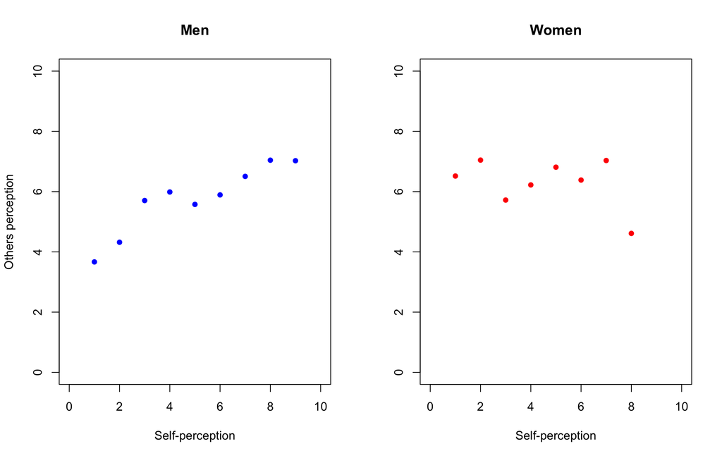

- Men show a high-degree of self-awareness regarding their attractiveness relative to other men.
- Men tend to consider the women they dated fairly attractive regardless of how these women are perceiving themselves. Interestingly though, women who consider themselves as the most attracive (score: 8), are perceived as the least attractive by their dating partners.

## Sincerity

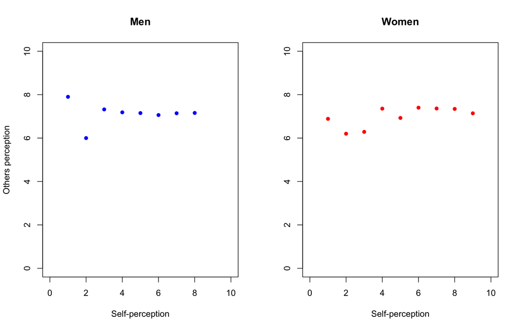

## Intelligence

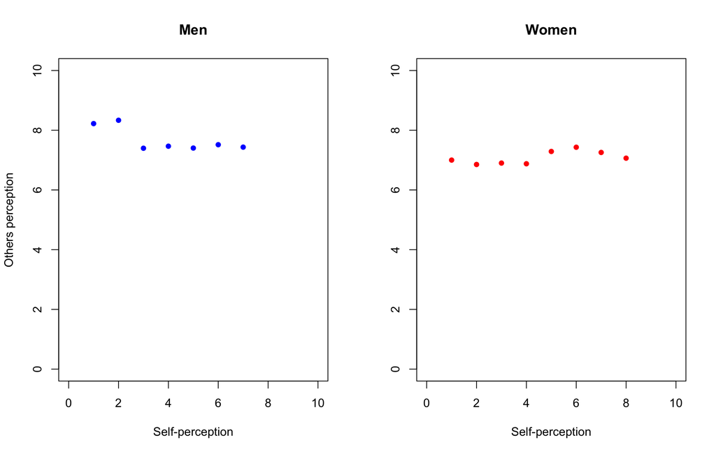

- Men who rate themselves very low with regards to their intelligence, are considered on average as the most intelligent by their dating partners, indicating that very smart people might also be the most modest.
- Women receive on average the same rating from their partners, regardless of how they pereceive themselves.

## Fun

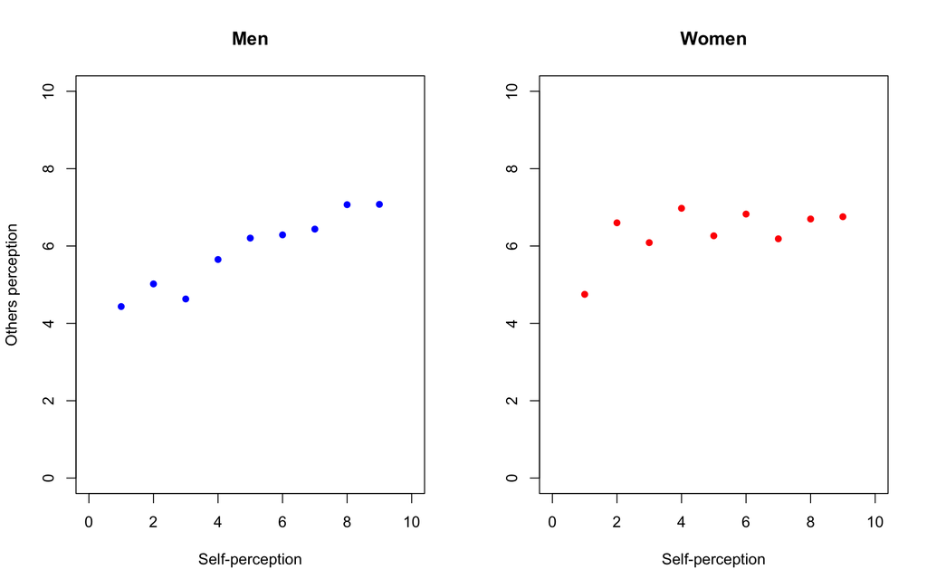

- Men show a high-degree of self-awareness with regards to how funny they are relative to other men.

## Ambition

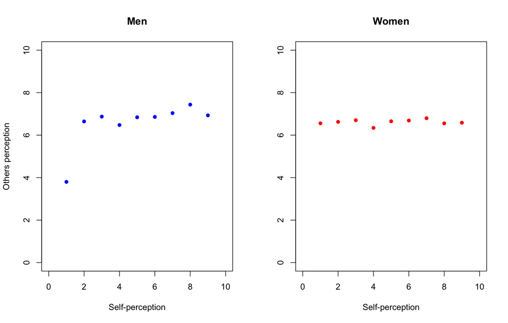

- Men with very low ambitions are easily recognized as such by their dating partners.
- Both men and women receive on average the same rating from their partners (score: ~7), regardless of how they pereceive themselves.